# KNN

Subhadeep Majumder

07-09-2021

# Creating A KNN Model On The Titanic Dataset

[figure not shown]

Sinking of the Titanic

## Importing The Required Libraries

### Well, first we import all the libraries required to develop the model:

```r
library(gt)
library(class)
library(caret)
library(GGally)
```

## Importing the given Dataset

```r
titanic_ds<-read.csv('titanic_ds.csv',stringsAsFactors = FALSE)
```

## Pre-processing The Data to Increase its Quality

### In this stage of Data Analysis, we transform the structure and type of the data to make it suitable for the analysis that is to follow.

### First, we change the categorical data of Sex(Male,Female) to a Numerical Form Sex(1,0):

```r
titanic_ds$Sex<-ifelse(titanic_ds$Sex== "male" ,1,0)
```

### Second, we change the Categorical data of Embarked(Q,S,C) to Embarked(0,1,2):

```r
 titanic_ds$Embarked[titanic_ds$Embarked=="Q"]<-0
 titanic_ds$Embarked[titanic_ds$Embarked=="S"]<-1
 titanic_ds$Embarked[titanic_ds$Embarked=="C"]<-2
```

### Now let’s take a look at our imported dataset:

```r
gt_preview(titanic_ds)
```

|  | PassengerId | Survived | Pclass | Name | Sex | Age | SibSp | Parch | Ticket | Fare | Cabin | Embarked |
| --- | --- | --- | --- | --- | --- | --- | --- | --- | --- | --- | --- | --- |
| 1 | 892 | 0 | 3 | Kelly, Mr. James | 1 | 34.5 | 0 | 0 | 330911 | 7.8292 |  | 0 |
| 2 | 893 | 1 | 3 | Wilkes, Mrs. James (Ellen Needs) | 0 | 47.0 | 1 | 0 | 363272 | 7.0000 |  | 1 |
| 3 | 894 | 0 | 2 | Myles, Mr. Thomas Francis | 1 | 62.0 | 0 | 0 | 240276 | 9.6875 |  | 0 |
| 4 | 895 | 0 | 3 | Wirz, Mr. Albert | 1 | 27.0 | 0 | 0 | 315154 | 8.6625 |  | 1 |
| 5 | 896 | 1 | 3 | Hirvonen, Mrs. Alexander (Helga E Lindqvist) | 0 | 22.0 | 1 | 1 | 3101298 | 12.2875 |  | 1 |
| 6..417 |  |  |  |  |  |  |  |  |  |  |  |  |
| 418 | 1309 | 0 | 3 | Peter, Master. Michael J | 1 | NA | 1 | 1 | 2668 | 22.3583 |  | 2 |

### We noticed that there are some columns that won’t contribute to building the KNN model like the PassengerID and Name column. So we remove them and Preview the clean data:

```r
titanic_clean<-titanic_ds[,c(2,3,5,6,7,8,10,12)]
gt_preview(titanic_clean)
```

|  | Survived | Pclass | Sex | Age | SibSp | Parch | Fare | Embarked |
| --- | --- | --- | --- | --- | --- | --- | --- | --- |
| 1 | 0 | 3 | 1 | 34.5 | 0 | 0 | 7.8292 | 0 |
| 2 | 1 | 3 | 0 | 47.0 | 1 | 0 | 7.0000 | 1 |
| 3 | 0 | 2 | 1 | 62.0 | 0 | 0 | 9.6875 | 0 |
| 4 | 0 | 3 | 1 | 27.0 | 0 | 0 | 8.6625 | 1 |
| 5 | 1 | 3 | 0 | 22.0 | 1 | 1 | 12.2875 | 1 |
| 6..417 |  |  |  |  |  |  |  |  |
| 418 | 0 | 3 | 1 | NA | 1 | 1 | 22.3583 | 2 |

### In the next step, we check if there are any missing values in the dataset:

```r
sum(is.na(titanic_clean))
```

```
## [1] 87
```

### As the attribute of interest based on which we need to classify the data is “Survived” where (Survived,Non-Survived):(1,0), we change the type of the Survival Data as Factors:

```r
titanic_clean$Survived<-as.factor(titanic_clean$Survived)
str(titanic_clean)
```

```
## 'data.frame':    418 obs. of  8 variables:
##  $ Survived: Factor w/ 2 levels "0","1": 1 2 1 1 2 1 2 1 2 1 ...
##  $ Pclass  : int  3 3 2 3 3 3 3 2 3 3 ...
##  $ Sex     : num  1 0 1 1 0 1 0 1 0 1 ...
##  $ Age     : num  34.5 47 62 27 22 14 30 26 18 21 ...
##  $ SibSp   : int  0 1 0 0 1 0 0 1 0 2 ...
##  $ Parch   : int  0 0 0 0 1 0 0 1 0 0 ...
##  $ Fare    : num  7.83 7 9.69 8.66 12.29 ...
##  $ Embarked: chr  "0" "1" "0" "1" ...
```

### Before we change the type of the data, let’s first locate the missing values and impute them:

```r
sum(is.na(titanic_clean$Age)) #86 missing values in Age column
```

```
## [1] 86
```

```r
sum(is.na(titanic_clean$Pclass))
```

```
## [1] 0
```

```r
sum(is.na(titanic_clean$Sex))
```

```
## [1] 0
```

```r
sum(is.na(titanic_clean$SibSp))
```

```
## [1] 0
```

```r
sum(is.na(titanic_clean$Fare))# 1 missing value in fare column
```

```
## [1] 1
```

### We impute the missing values in Age column with Median and that of Fare column with the Mode:

```r
getmode <- function(mode_fare) {
   uniqv <- unique(mode_fare)
   uniqv[which.max(tabulate(match(mode_fare, uniqv)))]
}
mode_fare<-titanic_clean$Fare

titanic_clean$Age[is.na(titanic_clean$Age)]<-median(titanic_clean$Age,na.rm = TRUE)
titanic_clean$Fare[is.na(titanic_clean$Fare)]<-getmode(mode_fare)
getmode(mode_fare)
```

```
## [1] 7.75
```

### Then we coerce all the columns in the dataset into numeric data type:

```r
titanic_clean$Embarked<-as.numeric(titanic_clean$Embarked)
titanic_clean$Pclass<-as.numeric(titanic_clean$Pclass)
titanic_clean$SibSp<-as.numeric(titanic_clean$SibSp)
titanic_clean$Parch<-as.numeric(titanic_clean$Parch)
titanic_clean$Fare<-as.numeric(titanic_clean$Fare)
str(titanic_clean)
```

```
## 'data.frame':    418 obs. of  8 variables:
##  $ Survived: Factor w/ 2 levels "0","1": 1 2 1 1 2 1 2 1 2 1 ...
##  $ Pclass  : num  3 3 2 3 3 3 3 2 3 3 ...
##  $ Sex     : num  1 0 1 1 0 1 0 1 0 1 ...
##  $ Age     : num  34.5 47 62 27 22 14 30 26 18 21 ...
##  $ SibSp   : num  0 1 0 0 1 0 0 1 0 2 ...
##  $ Parch   : num  0 0 0 0 1 0 0 1 0 0 ...
##  $ Fare    : num  7.83 7 9.69 8.66 12.29 ...
##  $ Embarked: num  0 1 0 1 1 1 0 1 2 1 ...
```

### We preview the final processed dataset again:

```r
gt_preview(titanic_clean)
```

|  | Survived | Pclass | Sex | Age | SibSp | Parch | Fare | Embarked |
| --- | --- | --- | --- | --- | --- | --- | --- | --- |
| 1 | 0 | 3 | 1 | 34.5 | 0 | 0 | 7.8292 | 0 |
| 2 | 1 | 3 | 0 | 47.0 | 1 | 0 | 7.0000 | 1 |
| 3 | 0 | 2 | 1 | 62.0 | 0 | 0 | 9.6875 | 0 |
| 4 | 0 | 3 | 1 | 27.0 | 0 | 0 | 8.6625 | 1 |
| 5 | 1 | 3 | 0 | 22.0 | 1 | 1 | 12.2875 | 1 |
| 6..417 |  |  |  |  |  |  |  |  |
| 418 | 0 | 3 | 1 | 27.0 | 1 | 1 | 22.3583 | 2 |

## Now we Start the Analysis Stage.

```r
normlz <-function(x) {return(x-as.numeric(mean(x)))/as.numeric(sd(x)) }
titanic_norm<-as.data.frame(lapply(titanic_clean[,2:8], normlz))
summary(titanic_norm)
```

```
##      Pclass             Sex               Age              SibSp
##  Min.   :-1.2656   Min.   :-0.6364   Min.   :-29.429   Min.   :-0.4474
##  1st Qu.:-1.2656   1st Qu.:-0.6364   1st Qu.: -6.599   1st Qu.:-0.4474
##  Median : 0.7344   Median : 0.3636   Median : -2.599   Median :-0.4474
##  Mean   : 0.0000   Mean   : 0.0000   Mean   :  0.000   Mean   : 0.0000
##  3rd Qu.: 0.7344   3rd Qu.: 0.3636   3rd Qu.:  6.151   3rd Qu.: 0.5526
##  Max.   : 0.7344   Max.   : 0.3636   Max.   : 46.401   Max.   : 7.5526
##      Parch              Fare            Embarked
##  Min.   :-0.3923   Min.   :-35.560   Min.   :-1.134
##  1st Qu.:-0.3923   1st Qu.:-27.665   1st Qu.:-0.134
##  Median :-0.3923   Median :-21.106   Median :-0.134
##  Mean   : 0.0000   Mean   :  0.000   Mean   : 0.000
##  3rd Qu.:-0.3923   3rd Qu.: -4.089   3rd Qu.:-0.134
##  Max.   : 8.6077   Max.   :476.769   Max.   : 0.866
```

### This plot observes the correlation between the different attributes:

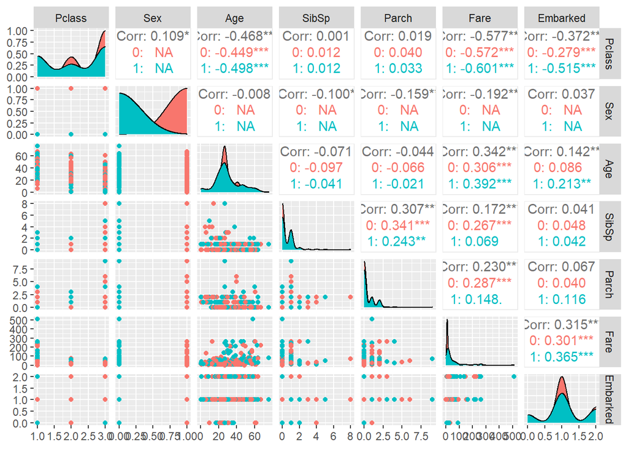

```r
ggpairs(titanic_clean,columns=2:8,mapping =aes(color=Survived))
```

### Then we split the Data frame into the Training Dataset and Testing Dataset:

```r
titanic_train<-titanic_norm[1:293,1:7]
titanic_test<-titanic_norm[294:418,1:7]
titanic_train_labels<-as.array(titanic_clean[1:293,1])
titanic_test_labels<-as.array(titanic_clean[294:418,1])
```

## Finding the Optimal Number Of Neighbours

### Here we create a loop to find the Percentage of Accuracy for each k from 1 to 25:

```r
i=1
k.optm=1
for (i in 1:25){
 knn.pred <- knn(train=titanic_train, test=titanic_test, cl=titanic_train_labels, k=i)
 k.optm[i] <- 100 * sum(titanic_test_labels == knn.pred)/NROW(titanic_test_labels)
 k=i
 cat(k,'=',k.optm[i],'
')

}
```

```
## 1 = 70.4
## 2 = 64.8
## 3 = 68
## 4 = 70.4
## 5 = 72
## 6 = 71.2
## 7 = 68.8
## 8 = 69.6
## 9 = 63.2
## 10 = 65.6
## 11 = 69.6
## 12 = 69.6
## 13 = 68.8
## 14 = 72
## 15 = 68
## 16 = 67.2
## 17 = 72
## 18 = 72
## 19 = 69.6
## 20 = 72.8
## 21 = 71.2
## 22 = 69.6
## 23 = 68.8
## 24 = 65.6
## 25 = 68
```

### Then we draw the accuracy plot and determine the value of k for which we have the highest Accuracy:

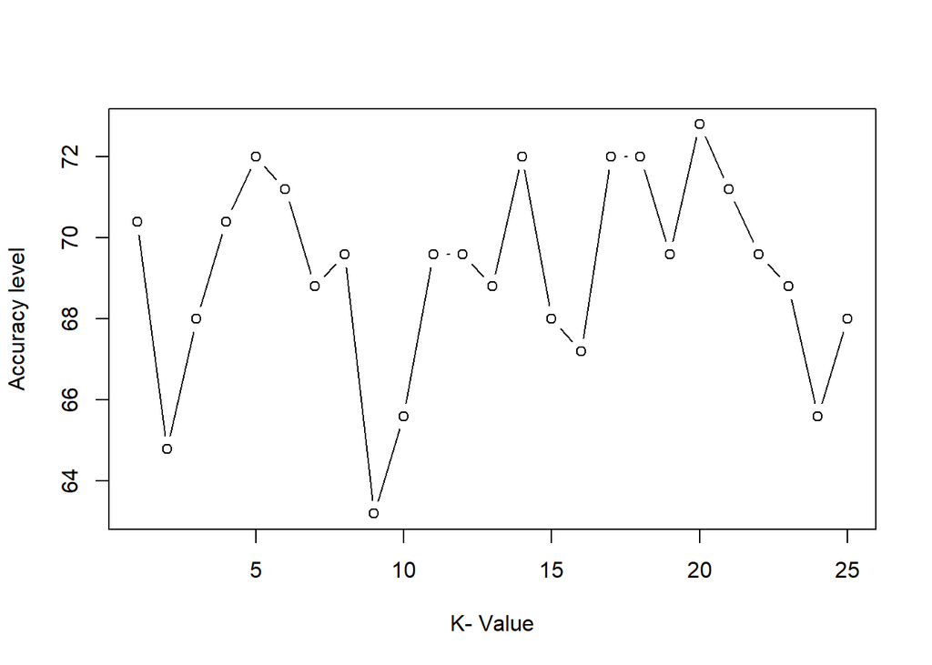

```r
acc_plot<-plot(k.optm, type="b", xlab="K- Value",ylab="Accuracy level")
```

### Thus, from the graph we see that the model has the best accuracy of 72.8% for K=20 neighbours.